# strucplot

#### Examples

```r
library(vcd)
```

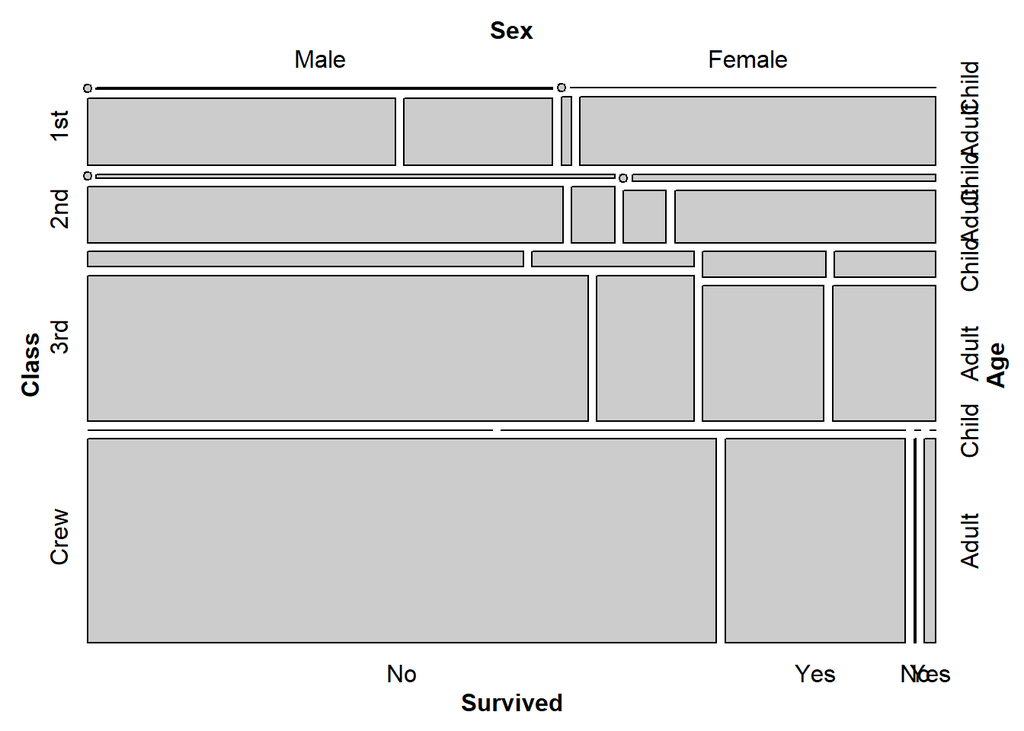

```r
data("Titanic")
strucplot(Titanic)
```

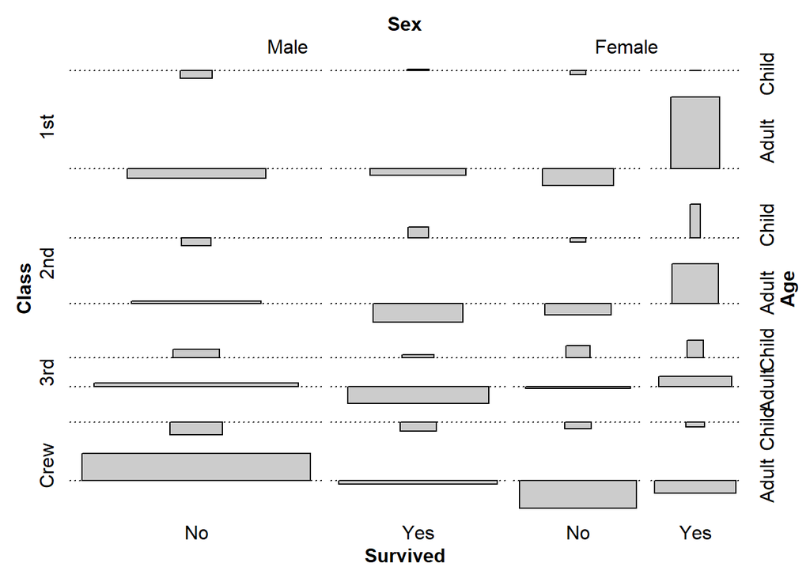

```r
strucplot(Titanic, core = struc_assoc)
```

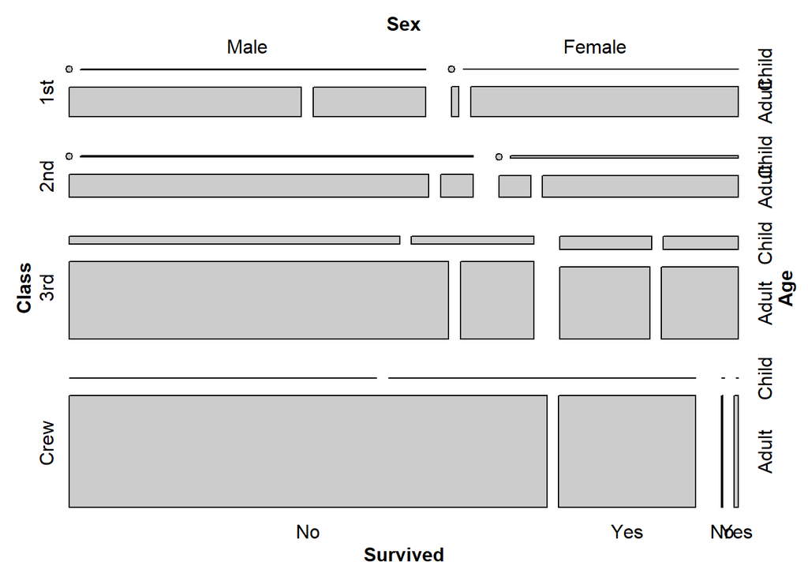

```r
strucplot(Titanic, spacing = spacing_increase,
spacing_args = list(start = 0.5, rate = 1.5))
```

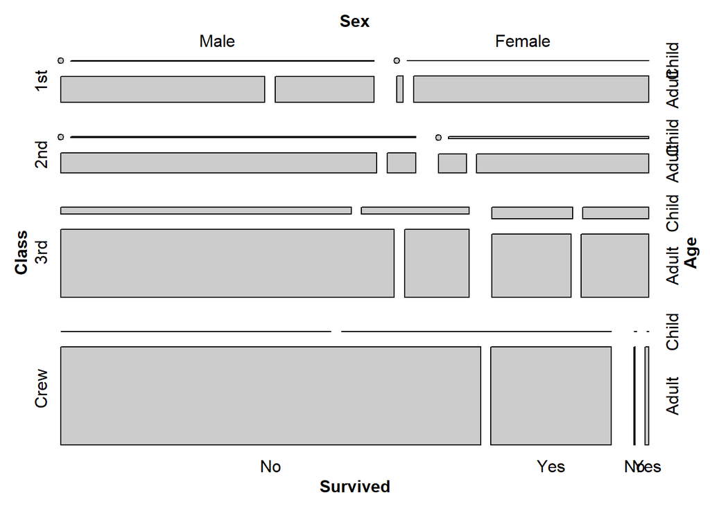

```r
strucplot(Titanic, spacing = spacing_increase(start = 0.5, rate = 1.5))
```

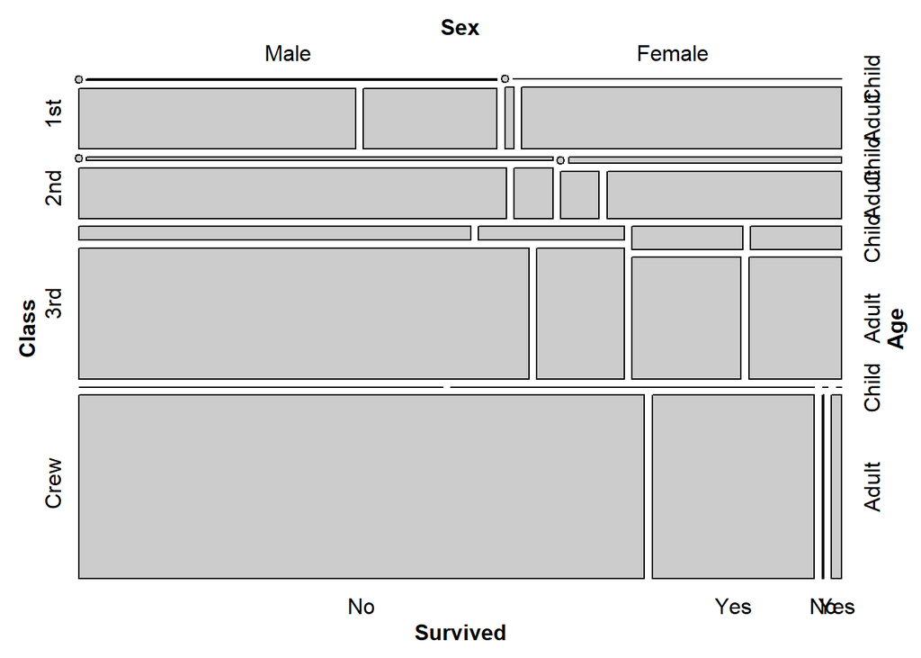

```r
## modify a tile's color
strucplot(Titanic, pop = FALSE)
```

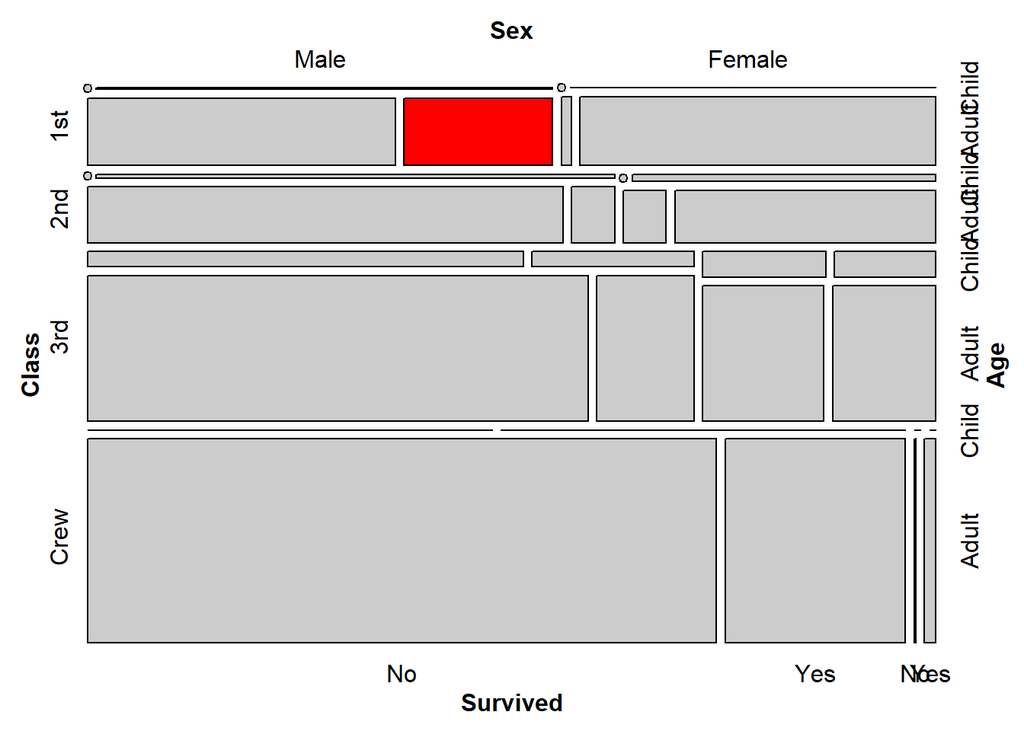

```r
grid.edit("rect:Class=1st,Sex=Male,Age=Adult,Survived=Yes",
gp = gpar(fill = "red"))
```